# Risk Factor Analysis

## Outcome Variable

**Outcome Variable:** haz

## Predictor Variables

**Intervention Variable:** perdiar24

**Adjustment Set:**

- arm
- sex
- meducyrs
- feducyrs
- hhwealth_quart
- hfoodsec
- vagbrth
- hdlvry
- W_birthwt
- W_birthlen
- single
- W_nrooms
- month
- brthmon
- impfloor
- impsan
- safeh20
- delta_meducyrs
- delta_feducyrs
- delta_hhwealth_quart
- delta_hfoodsec
- delta_vagbrth
- delta_hdlvry
- delta_W_birthwt
- delta_W_birthlen
- delta_single
- delta_W_nrooms
- delta_month
- delta_brthmon
- delta_impfloor
- delta_impsan
- delta_safeh20

## Stratifying Variables

The analysis was stratified on these variable(s):

- agecat
- studyid
- country

## Data Summary

| agecat | studyid | country | perdiar24 | n_cell | n |
| --- | --- | --- | --- | --- | --- |
| Birth | ki0047075b-MAL-ED | BANGLADESH | 0% | 18 | 231 |
| Birth | ki0047075b-MAL-ED | BANGLADESH | (0%, 5%] | 131 | 231 |
| Birth | ki0047075b-MAL-ED | BANGLADESH | >5% | 82 | 231 |
| Birth | ki0047075b-MAL-ED | BRAZIL | 0% | 34 | 65 |
| Birth | ki0047075b-MAL-ED | BRAZIL | (0%, 5%] | 29 | 65 |
| Birth | ki0047075b-MAL-ED | BRAZIL | >5% | 2 | 65 |
| Birth | ki0047075b-MAL-ED | INDIA | 0% | 5 | 47 |
| Birth | ki0047075b-MAL-ED | INDIA | (0%, 5%] | 33 | 47 |
| Birth | ki0047075b-MAL-ED | INDIA | >5% | 9 | 47 |
| Birth | ki0047075b-MAL-ED | NEPAL | 0% | 2 | 27 |
| Birth | ki0047075b-MAL-ED | NEPAL | (0%, 5%] | 19 | 27 |
| Birth | ki0047075b-MAL-ED | NEPAL | >5% | 6 | 27 |
| Birth | ki0047075b-MAL-ED | PERU | 0% | 21 | 233 |
| Birth | ki0047075b-MAL-ED | PERU | (0%, 5%] | 89 | 233 |
| Birth | ki0047075b-MAL-ED | PERU | >5% | 123 | 233 |
| Birth | ki0047075b-MAL-ED | SOUTH AFRICA | 0% | 42 | 113 |
| Birth | ki0047075b-MAL-ED | SOUTH AFRICA | (0%, 5%] | 70 | 113 |
| Birth | ki0047075b-MAL-ED | SOUTH AFRICA | >5% | 1 | 113 |
| Birth | ki0047075b-MAL-ED | TANZANIA, UNITED REPUBLIC OF | 0% | 9 | 125 |
| Birth | ki0047075b-MAL-ED | TANZANIA, UNITED REPUBLIC OF | (0%, 5%] | 85 | 125 |
| Birth | ki0047075b-MAL-ED | TANZANIA, UNITED REPUBLIC OF | >5% | 31 | 125 |
| Birth | ki1000109-EE | PAKISTAN | 0% | 161 | 240 |
| Birth | ki1000109-EE | PAKISTAN | (0%, 5%] | 79 | 240 |
| Birth | ki1000109-EE | PAKISTAN | >5% | 0 | 240 |
| Birth | ki1017093-NIH-Birth | BANGLADESH | 0% | 51 | 605 |
| Birth | ki1017093-NIH-Birth | BANGLADESH | (0%, 5%] | 345 | 605 |
| Birth | ki1017093-NIH-Birth | BANGLADESH | >5% | 209 | 605 |
| Birth | ki1017093b-PROVIDE | BANGLADESH | 0% | 55 | 539 |
| Birth | ki1017093b-PROVIDE | BANGLADESH | (0%, 5%] | 327 | 539 |
| Birth | ki1017093b-PROVIDE | BANGLADESH | >5% | 157 | 539 |

[output cut: 102 more lines]

The following strata were considered:

- agecat: 24 months, studyid: ki0047075b-MAL-ED, country: BANGLADESH
- agecat: 24 months, studyid: ki0047075b-MAL-ED, country: BRAZIL
- agecat: 24 months, studyid: ki0047075b-MAL-ED, country: INDIA
- agecat: 24 months, studyid: ki0047075b-MAL-ED, country: NEPAL
- agecat: 24 months, studyid: ki0047075b-MAL-ED, country: PERU
- agecat: 24 months, studyid: ki0047075b-MAL-ED, country: SOUTH AFRICA
- agecat: 24 months, studyid: ki0047075b-MAL-ED, country: TANZANIA, UNITED REPUBLIC OF
- agecat: 24 months, studyid: ki1000109-EE, country: PAKISTAN
- agecat: 24 months, studyid: ki1017093-NIH-Birth, country: BANGLADESH
- agecat: 24 months, studyid: ki1017093b-PROVIDE, country: BANGLADESH
- agecat: 24 months, studyid: ki1017093c-NIH-Crypto, country: BANGLADESH
- agecat: 24 months, studyid: ki1114097-CMIN, country: BANGLADESH
- agecat: 24 months, studyid: ki1114097-CONTENT, country: PERU
- agecat: 24 months, studyid: kiGH5241-JiVitA-4, country: BANGLADESH
- agecat: 6 months, studyid: ki0047075b-MAL-ED, country: BANGLADESH
- agecat: 6 months, studyid: ki0047075b-MAL-ED, country: BRAZIL
- agecat: 6 months, studyid: ki0047075b-MAL-ED, country: INDIA
- agecat: 6 months, studyid: ki0047075b-MAL-ED, country: NEPAL
- agecat: 6 months, studyid: ki0047075b-MAL-ED, country: PERU
- agecat: 6 months, studyid: ki0047075b-MAL-ED, country: SOUTH AFRICA
- agecat: 6 months, studyid: ki0047075b-MAL-ED, country: TANZANIA, UNITED REPUBLIC OF
- agecat: 6 months, studyid: ki1000109-EE, country: PAKISTAN
- agecat: 6 months, studyid: ki1000304b-SAS-FoodSuppl, country: INDIA
- agecat: 6 months, studyid: ki1017093-NIH-Birth, country: BANGLADESH
- agecat: 6 months, studyid: ki1017093b-PROVIDE, country: BANGLADESH
- agecat: 6 months, studyid: ki1017093c-NIH-Crypto, country: BANGLADESH
- agecat: 6 months, studyid: ki1112895-Guatemala BSC, country: GUATEMALA
- agecat: 6 months, studyid: ki1114097-CMIN, country: BANGLADESH
- agecat: 6 months, studyid: ki1114097-CONTENT, country: PERU
- agecat: 6 months, studyid: kiGH5241-JiVitA-4, country: BANGLADESH
- agecat: Birth, studyid: ki0047075b-MAL-ED, country: BANGLADESH
- agecat: Birth, studyid: ki0047075b-MAL-ED, country: BRAZIL
- agecat: Birth, studyid: ki0047075b-MAL-ED, country: INDIA
- agecat: Birth, studyid: ki0047075b-MAL-ED, country: NEPAL
- agecat: Birth, studyid: ki0047075b-MAL-ED, country: PERU
- agecat: Birth, studyid: ki0047075b-MAL-ED, country: SOUTH AFRICA
- agecat: Birth, studyid: ki0047075b-MAL-ED, country: TANZANIA, UNITED REPUBLIC OF
- agecat: Birth, studyid: ki1000109-EE, country: PAKISTAN
- agecat: Birth, studyid: ki1017093-NIH-Birth, country: BANGLADESH
- agecat: Birth, studyid: ki1017093b-PROVIDE, country: BANGLADESH
- agecat: Birth, studyid: ki1017093c-NIH-Crypto, country: BANGLADESH
- agecat: Birth, studyid: ki1114097-CMIN, country: BANGLADESH
- agecat: Birth, studyid: ki1114097-CONTENT, country: PERU
- agecat: Birth, studyid: kiGH5241-JiVitA-4, country: BANGLADESH

### Dropped Strata

Some strata were dropped due to rare outcomes:

- agecat: Birth, studyid: ki0047075b-MAL-ED, country: BRAZIL
- agecat: Birth, studyid: ki0047075b-MAL-ED, country: NEPAL
- agecat: Birth, studyid: ki0047075b-MAL-ED, country: SOUTH AFRICA
- agecat: Birth, studyid: ki1000109-EE, country: PAKISTAN
- agecat: Birth, studyid: ki1114097-CMIN, country: BANGLADESH
- agecat: Birth, studyid: ki1114097-CONTENT, country: PERU
- agecat: 6 months, studyid: ki0047075b-MAL-ED, country: BRAZIL
- agecat: 6 months, studyid: ki0047075b-MAL-ED, country: INDIA
- agecat: 6 months, studyid: ki0047075b-MAL-ED, country: SOUTH AFRICA
- agecat: 6 months, studyid: ki1000109-EE, country: PAKISTAN
- agecat: 6 months, studyid: ki1114097-CMIN, country: BANGLADESH
- agecat: 24 months, studyid: ki0047075b-MAL-ED, country: BRAZIL
- agecat: 24 months, studyid: ki0047075b-MAL-ED, country: INDIA
- agecat: 24 months, studyid: ki0047075b-MAL-ED, country: PERU
- agecat: 24 months, studyid: ki0047075b-MAL-ED, country: SOUTH AFRICA
- agecat: 24 months, studyid: ki1000109-EE, country: PAKISTAN
- agecat: 24 months, studyid: ki1114097-CMIN, country: BANGLADESH
- agecat: 24 months, studyid: ki1114097-CONTENT, country: PERU

## Methods Detail

We’re interested in the causal parameters $E[Y_a]$ for all values of $a \in \mathcal{A}$. These parameters represent the mean outcome if, possibly contrary to fact, we intervened to set all units to have $A=a$. Under the randomization and positivity assumptions, these are identified by the statistical parameters $\psi_a=E_W[E_{Y|A,W}(Y|A=a,W)]$. In addition, we’re interested in the mean of $Y$, $E[Y]$ under no intervention (the observed mean). We will estimate these parameters by using SuperLearner to fit the relevant likelihood factors – $E_{Y|A,W}(Y|A=a,W)$ and $p(A=a|W)$, and then updating our likelihood fit using a joint TMLE.

For unadjusted analyses ($W=\{\}$), initial likelihoods were estimated using Lrnr_glm to estimate the simple $E(Y|A)$ and Lrnr_mean to estimate $p(A)$. For adjusted analyses, a small library containing Lrnr_glmnet, Lrnr_xgboost, and Lrnr_mean was used.

Having estimated these parameters, we will then use the delta method to estimate relative risks and attributable risks relative to a prespecified baseline level of $A$.

# Results Detail

## Results Plots

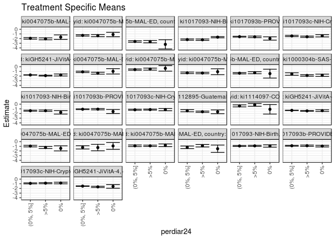

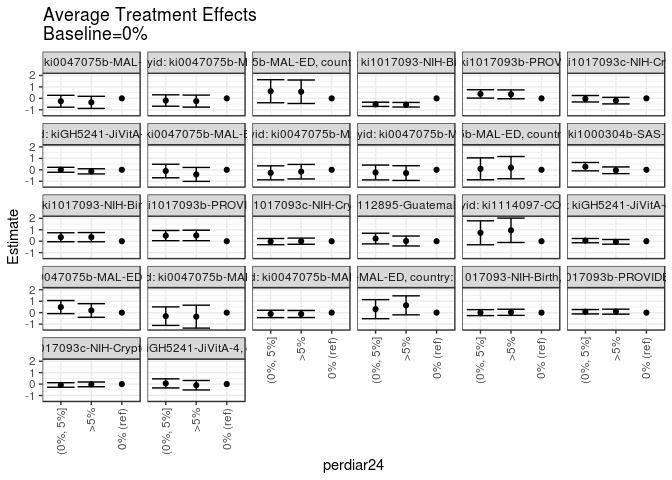

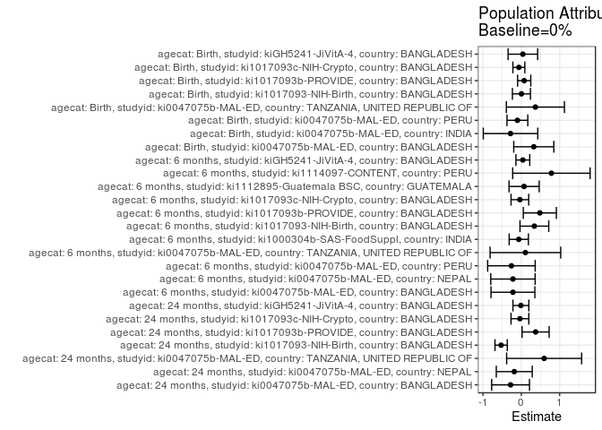

## Results Table

### Parameter: TSM

| agecat | studyid | country | intervention_level | baseline_level | estimate | ci_lower | ci_upper |
| --- | --- | --- | --- | --- | --- | --- | --- |
| Birth | ki0047075b-MAL-ED | BANGLADESH | 0% | NA | -1.4430653 | -1.9915562 | -0.8945744 |
| Birth | ki0047075b-MAL-ED | BANGLADESH | (0%, 5%] | NA | -0.9571172 | -1.1268467 | -0.7873877 |
| Birth | ki0047075b-MAL-ED | BANGLADESH | >5% | NA | -1.2543383 | -1.4851150 | -1.0235615 |
| Birth | ki0047075b-MAL-ED | INDIA | 0% | NA | -0.9220000 | -1.6509223 | -0.1930777 |
| Birth | ki0047075b-MAL-ED | INDIA | (0%, 5%] | NA | -1.2281818 | -1.5833498 | -0.8730139 |
| Birth | ki0047075b-MAL-ED | INDIA | >5% | NA | -1.2700000 | -1.9601079 | -0.5798921 |
| Birth | ki0047075b-MAL-ED | PERU | 0% | NA | -0.7801957 | -1.0678087 | -0.4925827 |
| Birth | ki0047075b-MAL-ED | PERU | (0%, 5%] | NA | -0.8916370 | -1.0643473 | -0.7189268 |
| Birth | ki0047075b-MAL-ED | PERU | >5% | NA | -0.8990223 | -1.0475959 | -0.7504488 |
| Birth | ki0047075b-MAL-ED | TANZANIA, UNITED REPUBLIC OF | 0% | NA | -1.5222222 | -2.3091001 | -0.7353443 |
| Birth | ki0047075b-MAL-ED | TANZANIA, UNITED REPUBLIC OF | (0%, 5%] | NA | -1.2164706 | -1.4939186 | -0.9390226 |
| Birth | ki0047075b-MAL-ED | TANZANIA, UNITED REPUBLIC OF | >5% | NA | -0.8822581 | -1.1471959 | -0.6173203 |
| Birth | ki1017093-NIH-Birth | BANGLADESH | 0% | NA | -0.9340889 | -1.1862419 | -0.6819360 |
| Birth | ki1017093-NIH-Birth | BANGLADESH | (0%, 5%] | NA | -0.9305142 | -1.0385803 | -0.8224481 |
| Birth | ki1017093-NIH-Birth | BANGLADESH | >5% | NA | -0.9046945 | -1.0269378 | -0.7824513 |
| Birth | ki1017093b-PROVIDE | BANGLADESH | 0% | NA | -0.9598370 | -1.1383791 | -0.7812949 |
| Birth | ki1017093b-PROVIDE | BANGLADESH | (0%, 5%] | NA | -0.8797279 | -0.9711106 | -0.7883453 |
| Birth | ki1017093b-PROVIDE | BANGLADESH | >5% | NA | -0.8714362 | -1.0093462 | -0.7335262 |
| Birth | ki1017093c-NIH-Crypto | BANGLADESH | 0% | NA | -0.8455307 | -1.0181192 | -0.6729423 |
| Birth | ki1017093c-NIH-Crypto | BANGLADESH | (0%, 5%] | NA | -0.9213590 | -1.0305657 | -0.8121524 |
| Birth | ki1017093c-NIH-Crypto | BANGLADESH | >5% | NA | -0.8708469 | -0.9950626 | -0.7466312 |
| Birth | kiGH5241-JiVitA-4 | BANGLADESH | 0% | NA | -1.5632085 | -1.9549170 | -1.1715001 |
| Birth | kiGH5241-JiVitA-4 | BANGLADESH | (0%, 5%] | NA | -1.5031843 | -1.5561069 | -1.4502617 |
| Birth | kiGH5241-JiVitA-4 | BANGLADESH | >5% | NA | -1.6639576 | -1.7928314 | -1.5350839 |
| 6 months | ki0047075b-MAL-ED | BANGLADESH | 0% | NA | -0.9866667 | -1.5612360 | -0.4120973 |
| 6 months | ki0047075b-MAL-ED | BANGLADESH | (0%, 5%] | NA | -1.0940728 | -1.2377770 | -0.9503685 |
| 6 months | ki0047075b-MAL-ED | BANGLADESH | >5% | NA | -1.3897312 | -1.5914982 | -1.1879641 |
| 6 months | ki0047075b-MAL-ED | NEPAL | 0% | NA | -0.3426281 | -0.9400032 | 0.2547470 |
| 6 months | ki0047075b-MAL-ED | NEPAL | (0%, 5%] | NA | -0.6083368 | -0.7456637 | -0.4710099 |
| 6 months | ki0047075b-MAL-ED | NEPAL | >5% | NA | -0.5080318 | -0.7212686 | -0.2947950 |
| 6 months | ki0047075b-MAL-ED | PERU | 0% | NA | -1.0700000 | -1.6970711 | -0.4429289 |
| 6 months | ki0047075b-MAL-ED | PERU | (0%, 5%] | NA | -1.3052752 | -1.4678559 | -1.1426946 |
| 6 months | ki0047075b-MAL-ED | PERU | >5% | NA | -1.3554459 | -1.5031027 | -1.2077890 |
| 6 months | ki0047075b-MAL-ED | TANZANIA, UNITED REPUBLIC OF | 0% | NA | -1.4750000 | -2.4233687 | -0.5266313 |
| 6 months | ki0047075b-MAL-ED | TANZANIA, UNITED REPUBLIC OF | (0%, 5%] | NA | -1.3915631 | -1.5359143 | -1.2472119 |
| 6 months | ki0047075b-MAL-ED | TANZANIA, UNITED REPUBLIC OF | >5% | NA | -1.2868579 | -1.5070055 | -1.0667103 |
| 6 months | ki1000304b-SAS-FoodSuppl | INDIA | 0% | NA | -1.8324910 | -2.0762765 | -1.5887054 |
| 6 months | ki1000304b-SAS-FoodSuppl | INDIA | (0%, 5%] | NA | -1.5606343 | -1.8315548 | -1.2897138 |
| 6 months | ki1000304b-SAS-FoodSuppl | INDIA | >5% | NA | -1.8753488 | -2.0349146 | -1.7157829 |
| 6 months | ki1017093-NIH-Birth | BANGLADESH | 0% | NA | -1.7473800 | -2.1220989 | -1.3726611 |
| 6 months | ki1017093-NIH-Birth | BANGLADESH | (0%, 5%] | NA | -1.3998691 | -1.5136786 | -1.2860596 |
| 6 months | ki1017093-NIH-Birth | BANGLADESH | >5% | NA | -1.3942663 | -1.5420056 | -1.2465270 |
| 6 months | ki1017093b-PROVIDE | BANGLADESH | 0% | NA | -1.5746406 | -2.0101415 | -1.1391397 |
| 6 months | ki1017093b-PROVIDE | BANGLADESH | (0%, 5%] | NA | -1.0830337 | -1.1711965 | -0.9948709 |
| 6 months | ki1017093b-PROVIDE | BANGLADESH | >5% | NA | -1.0691924 | -1.2138733 | -0.9245116 |
| 6 months | ki1017093c-NIH-Crypto | BANGLADESH | 0% | NA | -1.1607748 | -1.4056998 | -0.9158498 |
| 6 months | ki1017093c-NIH-Crypto | BANGLADESH | (0%, 5%] | NA | -1.1943629 | -1.3098156 | -1.0789102 |
| 6 months | ki1017093c-NIH-Crypto | BANGLADESH | >5% | NA | -1.1587801 | -1.2732377 | -1.0443225 |
| 6 months | ki1112895-Guatemala BSC | GUATEMALA | 0% | NA | -1.6343045 | -2.0469852 | -1.2216238 |
| 6 months | ki1112895-Guatemala BSC | GUATEMALA | (0%, 5%] | NA | -1.4032822 | -1.6285169 | -1.1780476 |
| 6 months | ki1112895-Guatemala BSC | GUATEMALA | >5% | NA | -1.6153045 | -1.7525291 | -1.4780799 |
| 6 months | ki1114097-CONTENT | PERU | 0% | NA | -1.0984167 | -2.1224703 | -0.0743631 |
| 6 months | ki1114097-CONTENT | PERU | (0%, 5%] | NA | -0.3610399 | -0.5741415 | -0.1479383 |
| 6 months | ki1114097-CONTENT | PERU | >5% | NA | -0.1438060 | -0.4445075 | 0.1568956 |
| 6 months | kiGH5241-JiVitA-4 | BANGLADESH | 0% | NA | -1.3841133 | -1.5668700 | -1.2013567 |
| 6 months | kiGH5241-JiVitA-4 | BANGLADESH | (0%, 5%] | NA | -1.3321268 | -1.3729609 | -1.2912927 |
| 6 months | kiGH5241-JiVitA-4 | BANGLADESH | >5% | NA | -1.4378173 | -1.5275871 | -1.3480476 |
| 24 months | ki0047075b-MAL-ED | BANGLADESH | 0% | NA | -1.6983333 | -2.1891875 | -1.2074792 |
| 24 months | ki0047075b-MAL-ED | BANGLADESH | (0%, 5%] | NA | -1.9508077 | -2.1168235 | -1.7847919 |
| 24 months | ki0047075b-MAL-ED | BANGLADESH | >5% | NA | -2.0491447 | -2.2540116 | -1.8442779 |
| 24 months | ki0047075b-MAL-ED | NEPAL | 0% | NA | -1.1274512 | -1.6042759 | -0.6506265 |
| 24 months | ki0047075b-MAL-ED | NEPAL | (0%, 5%] | NA | -1.3175901 | -1.4665369 | -1.1686433 |
| 24 months | ki0047075b-MAL-ED | NEPAL | >5% | NA | -1.3690968 | -1.5911397 | -1.1470538 |
| 24 months | ki0047075b-MAL-ED | TANZANIA, UNITED REPUBLIC OF | 0% | NA | -3.2400000 | -4.2371443 | -2.2428557 |
| 24 months | ki0047075b-MAL-ED | TANZANIA, UNITED REPUBLIC OF | (0%, 5%] | NA | -2.6170513 | -2.7775515 | -2.4565510 |
| 24 months | ki0047075b-MAL-ED | TANZANIA, UNITED REPUBLIC OF | >5% | NA | -2.6608654 | -2.9071887 | -2.4145421 |
| 24 months | ki1017093-NIH-Birth | BANGLADESH | 0% | NA | -1.6920000 | -1.8179481 | -1.5660519 |
| 24 months | ki1017093-NIH-Birth | BANGLADESH | (0%, 5%] | NA | -2.2130914 | -2.3480900 | -2.0780928 |
| 24 months | ki1017093-NIH-Birth | BANGLADESH | >5% | NA | -2.2487126 | -2.4051224 | -2.0923029 |
| 24 months | ki1017093b-PROVIDE | BANGLADESH | 0% | NA | -1.9750000 | -2.3266294 | -1.6233706 |
| 24 months | ki1017093b-PROVIDE | BANGLADESH | (0%, 5%] | NA | -1.5859747 | -1.6839331 | -1.4880162 |
| 24 months | ki1017093b-PROVIDE | BANGLADESH | >5% | NA | -1.6204885 | -1.7821075 | -1.4588695 |
| 24 months | ki1017093c-NIH-Crypto | BANGLADESH | 0% | NA | -1.4045158 | -1.6525638 | -1.1564679 |
| 24 months | ki1017093c-NIH-Crypto | BANGLADESH | (0%, 5%] | NA | -1.4382886 | -1.5759848 | -1.3005923 |
| 24 months | ki1017093c-NIH-Crypto | BANGLADESH | >5% | NA | -1.6030105 | -1.7445700 | -1.4614509 |
| 24 months | kiGH5241-JiVitA-4 | BANGLADESH | 0% | NA | -1.7692943 | -1.9810553 | -1.5575333 |
| 24 months | kiGH5241-JiVitA-4 | BANGLADESH | (0%, 5%] | NA | -1.7659785 | -1.8032630 | -1.7286940 |
| 24 months | kiGH5241-JiVitA-4 | BANGLADESH | >5% | NA | -1.9049401 | -1.9952599 | -1.8146202 |

### Parameter: E(Y)

| agecat | studyid | country | intervention_level | baseline_level | estimate | ci_lower | ci_upper |
| --- | --- | --- | --- | --- | --- | --- | --- |
| Birth | ki0047075b-MAL-ED | BANGLADESH | NA | NA | -1.1180952 | -1.2525408 | -0.9836496 |
| Birth | ki0047075b-MAL-ED | INDIA | NA | NA | -1.2036170 | -1.4976814 | -0.9095527 |
| Birth | ki0047075b-MAL-ED | PERU | NA | NA | -0.8827897 | -1.0001058 | -0.7654736 |
| Birth | ki0047075b-MAL-ED | TANZANIA, UNITED REPUBLIC OF | NA | NA | -1.1556000 | -1.3655361 | -0.9456639 |
| Birth | ki1017093-NIH-Birth | BANGLADESH | NA | NA | -0.9314050 | -1.0202164 | -0.8425936 |
| Birth | ki1017093b-PROVIDE | BANGLADESH | NA | NA | -0.8851020 | -0.9601332 | -0.8100709 |
| Birth | ki1017093c-NIH-Crypto | BANGLADESH | NA | NA | -0.9094945 | -0.9809370 | -0.8380521 |
| Birth | kiGH5241-JiVitA-4 | BANGLADESH | NA | NA | -1.5232908 | -1.5723277 | -1.4742539 |
| 6 months | ki0047075b-MAL-ED | BANGLADESH | NA | NA | -1.2054910 | -1.3228953 | -1.0880867 |
| 6 months | ki0047075b-MAL-ED | NEPAL | NA | NA | -0.5610593 | -0.6737915 | -0.4483272 |
| 6 months | ki0047075b-MAL-ED | PERU | NA | NA | -1.3280952 | -1.4363364 | -1.2198541 |
| 6 months | ki0047075b-MAL-ED | TANZANIA, UNITED REPUBLIC OF | NA | NA | -1.3687449 | -1.4907629 | -1.2467270 |
| 6 months | ki1000304b-SAS-FoodSuppl | INDIA | NA | NA | -1.8986842 | -2.0118892 | -1.7854792 |
| 6 months | ki1017093-NIH-Birth | BANGLADESH | NA | NA | -1.4073821 | -1.4960598 | -1.3187043 |
| 6 months | ki1017093b-PROVIDE | BANGLADESH | NA | NA | -1.0916915 | -1.1661176 | -1.0172654 |
| 6 months | ki1017093c-NIH-Crypto | BANGLADESH | NA | NA | -1.1986783 | -1.2700937 | -1.1272630 |
| 6 months | ki1112895-Guatemala BSC | GUATEMALA | NA | NA | -1.5619008 | -1.6727702 | -1.4510313 |
| 6 months | ki1114097-CONTENT | PERU | NA | NA | -0.3139217 | -0.4868486 | -0.1409948 |
| 6 months | kiGH5241-JiVitA-4 | BANGLADESH | NA | NA | -1.3447940 | -1.3820261 | -1.3075620 |
| 24 months | ki0047075b-MAL-ED | BANGLADESH | NA | NA | -1.9789151 | -2.1055330 | -1.8522972 |
| 24 months | ki0047075b-MAL-ED | NEPAL | NA | NA | -1.3118640 | -1.4315132 | -1.1922149 |
| 24 months | ki0047075b-MAL-ED | TANZANIA, UNITED REPUBLIC OF | NA | NA | -2.6451636 | -2.7802323 | -2.5100948 |
| 24 months | ki1017093-NIH-Birth | BANGLADESH | NA | NA | -2.2190579 | -2.3217459 | -2.1163699 |
| 24 months | ki1017093b-PROVIDE | BANGLADESH | NA | NA | -1.6024221 | -1.6857420 | -1.5191023 |
| 24 months | ki1017093c-NIH-Crypto | BANGLADESH | NA | NA | -1.4412646 | -1.5249156 | -1.3576135 |
| 24 months | kiGH5241-JiVitA-4 | BANGLADESH | NA | NA | -1.7807218 | -1.8162478 | -1.7451958 |

### Parameter: ATE

| agecat | studyid | country | intervention_level | baseline_level | estimate | ci_lower | ci_upper |
| --- | --- | --- | --- | --- | --- | --- | --- |
| Birth | ki0047075b-MAL-ED | BANGLADESH | 0% | 0% | 0.0000000 | 0.0000000 | 0.0000000 |
| Birth | ki0047075b-MAL-ED | BANGLADESH | (0%, 5%] | 0% | 0.4859481 | -0.0876885 | 1.0595847 |
| Birth | ki0047075b-MAL-ED | BANGLADESH | >5% | 0% | 0.1887270 | -0.4075289 | 0.7849830 |
| Birth | ki0047075b-MAL-ED | INDIA | 0% | 0% | 0.0000000 | 0.0000000 | 0.0000000 |
| Birth | ki0047075b-MAL-ED | INDIA | (0%, 5%] | 0% | -0.3061818 | -1.1170283 | 0.5046647 |
| Birth | ki0047075b-MAL-ED | INDIA | >5% | 0% | -0.3480000 | -1.3517812 | 0.6557812 |
| Birth | ki0047075b-MAL-ED | PERU | 0% | 0% | 0.0000000 | 0.0000000 | 0.0000000 |
| Birth | ki0047075b-MAL-ED | PERU | (0%, 5%] | 0% | -0.1114414 | -0.4328733 | 0.2099906 |
| Birth | ki0047075b-MAL-ED | PERU | >5% | 0% | -0.1188267 | -0.4280147 | 0.1903614 |
| Birth | ki0047075b-MAL-ED | TANZANIA, UNITED REPUBLIC OF | 0% | 0% | 0.0000000 | 0.0000000 | 0.0000000 |
| Birth | ki0047075b-MAL-ED | TANZANIA, UNITED REPUBLIC OF | (0%, 5%] | 0% | 0.3057516 | -0.5286070 | 1.1401102 |
| Birth | ki0047075b-MAL-ED | TANZANIA, UNITED REPUBLIC OF | >5% | 0% | 0.6399642 | -0.1903183 | 1.4702466 |
| Birth | ki1017093-NIH-Birth | BANGLADESH | 0% | 0% | 0.0000000 | 0.0000000 | 0.0000000 |
| Birth | ki1017093-NIH-Birth | BANGLADESH | (0%, 5%] | 0% | 0.0035747 | -0.2575443 | 0.2646938 |
| Birth | ki1017093-NIH-Birth | BANGLADESH | >5% | 0% | 0.0293944 | -0.2393066 | 0.2980954 |
| Birth | ki1017093b-PROVIDE | BANGLADESH | 0% | 0% | 0.0000000 | 0.0000000 | 0.0000000 |
| Birth | ki1017093b-PROVIDE | BANGLADESH | (0%, 5%] | 0% | 0.0801091 | -0.1126925 | 0.2729106 |
| Birth | ki1017093b-PROVIDE | BANGLADESH | >5% | 0% | 0.0884008 | -0.1290733 | 0.3058749 |
| Birth | ki1017093c-NIH-Crypto | BANGLADESH | 0% | 0% | 0.0000000 | 0.0000000 | 0.0000000 |
| Birth | ki1017093c-NIH-Crypto | BANGLADESH | (0%, 5%] | 0% | -0.0758283 | -0.2738300 | 0.1221735 |
| Birth | ki1017093c-NIH-Crypto | BANGLADESH | >5% | 0% | -0.0253161 | -0.2323474 | 0.1817152 |
| Birth | kiGH5241-JiVitA-4 | BANGLADESH | 0% | 0% | 0.0000000 | 0.0000000 | 0.0000000 |
| Birth | kiGH5241-JiVitA-4 | BANGLADESH | (0%, 5%] | 0% | 0.0600242 | -0.3364070 | 0.4564554 |
| Birth | kiGH5241-JiVitA-4 | BANGLADESH | >5% | 0% | -0.1007491 | -0.5130399 | 0.3115416 |
| 6 months | ki0047075b-MAL-ED | BANGLADESH | 0% | 0% | 0.0000000 | 0.0000000 | 0.0000000 |
| 6 months | ki0047075b-MAL-ED | BANGLADESH | (0%, 5%] | 0% | -0.1074061 | -0.6996736 | 0.4848614 |
| 6 months | ki0047075b-MAL-ED | BANGLADESH | >5% | 0% | -0.4030645 | -1.0120307 | 0.2059017 |
| 6 months | ki0047075b-MAL-ED | NEPAL | 0% | 0% | 0.0000000 | 0.0000000 | 0.0000000 |
| 6 months | ki0047075b-MAL-ED | NEPAL | (0%, 5%] | 0% | -0.2657087 | -0.8788687 | 0.3474513 |
| 6 months | ki0047075b-MAL-ED | NEPAL | >5% | 0% | -0.1654037 | -0.7998589 | 0.4690516 |
| 6 months | ki0047075b-MAL-ED | PERU | 0% | 0% | 0.0000000 | 0.0000000 | 0.0000000 |
| 6 months | ki0047075b-MAL-ED | PERU | (0%, 5%] | 0% | -0.2352752 | -0.8830797 | 0.4125293 |
| 6 months | ki0047075b-MAL-ED | PERU | >5% | 0% | -0.2854459 | -0.9296669 | 0.3587752 |
| 6 months | ki0047075b-MAL-ED | TANZANIA, UNITED REPUBLIC OF | 0% | 0% | 0.0000000 | 0.0000000 | 0.0000000 |
| 6 months | ki0047075b-MAL-ED | TANZANIA, UNITED REPUBLIC OF | (0%, 5%] | 0% | 0.0834369 | -0.8758547 | 1.0427285 |
| 6 months | ki0047075b-MAL-ED | TANZANIA, UNITED REPUBLIC OF | >5% | 0% | 0.1881421 | -0.7854431 | 1.1617272 |
| 6 months | ki1000304b-SAS-FoodSuppl | INDIA | 0% | 0% | 0.0000000 | 0.0000000 | 0.0000000 |
| 6 months | ki1000304b-SAS-FoodSuppl | INDIA | (0%, 5%] | 0% | 0.2718567 | -0.0933554 | 0.6370688 |
| 6 months | ki1000304b-SAS-FoodSuppl | INDIA | >5% | 0% | -0.0428578 | -0.3354486 | 0.2497329 |
| 6 months | ki1017093-NIH-Birth | BANGLADESH | 0% | 0% | 0.0000000 | 0.0000000 | 0.0000000 |
| 6 months | ki1017093-NIH-Birth | BANGLADESH | (0%, 5%] | 0% | 0.3475109 | -0.0443415 | 0.7393633 |
| 6 months | ki1017093-NIH-Birth | BANGLADESH | >5% | 0% | 0.3531137 | -0.0495989 | 0.7558264 |
| 6 months | ki1017093b-PROVIDE | BANGLADESH | 0% | 0% | 0.0000000 | 0.0000000 | 0.0000000 |
| 6 months | ki1017093b-PROVIDE | BANGLADESH | (0%, 5%] | 0% | 0.4916069 | 0.0472438 | 0.9359701 |
| 6 months | ki1017093b-PROVIDE | BANGLADESH | >5% | 0% | 0.5054482 | 0.0467070 | 0.9641894 |
| 6 months | ki1017093c-NIH-Crypto | BANGLADESH | 0% | 0% | 0.0000000 | 0.0000000 | 0.0000000 |
| 6 months | ki1017093c-NIH-Crypto | BANGLADESH | (0%, 5%] | 0% | -0.0335881 | -0.3036195 | 0.2364432 |
| 6 months | ki1017093c-NIH-Crypto | BANGLADESH | >5% | 0% | 0.0019947 | -0.2670111 | 0.2710005 |
| 6 months | ki1112895-Guatemala BSC | GUATEMALA | 0% | 0% | 0.0000000 | 0.0000000 | 0.0000000 |
| 6 months | ki1112895-Guatemala BSC | GUATEMALA | (0%, 5%] | 0% | 0.2310223 | -0.2362356 | 0.6982801 |
| 6 months | ki1112895-Guatemala BSC | GUATEMALA | >5% | 0% | 0.0190000 | -0.4158033 | 0.4538034 |
| 6 months | ki1114097-CONTENT | PERU | 0% | 0% | 0.0000000 | 0.0000000 | 0.0000000 |
| 6 months | ki1114097-CONTENT | PERU | (0%, 5%] | 0% | 0.7373768 | -0.3086147 | 1.7833682 |
| 6 months | ki1114097-CONTENT | PERU | >5% | 0% | 0.9546107 | -0.1126790 | 2.0219003 |
| 6 months | kiGH5241-JiVitA-4 | BANGLADESH | 0% | 0% | 0.0000000 | 0.0000000 | 0.0000000 |
| 6 months | kiGH5241-JiVitA-4 | BANGLADESH | (0%, 5%] | 0% | 0.0519865 | -0.1345462 | 0.2385193 |
| 6 months | kiGH5241-JiVitA-4 | BANGLADESH | >5% | 0% | -0.0537040 | -0.2592592 | 0.1518512 |
| 24 months | ki0047075b-MAL-ED | BANGLADESH | 0% | 0% | 0.0000000 | 0.0000000 | 0.0000000 |
| 24 months | ki0047075b-MAL-ED | BANGLADESH | (0%, 5%] | 0% | -0.2524744 | -0.7706433 | 0.2656946 |
| 24 months | ki0047075b-MAL-ED | BANGLADESH | >5% | 0% | -0.3508114 | -0.8827026 | 0.1810798 |
| 24 months | ki0047075b-MAL-ED | NEPAL | 0% | 0% | 0.0000000 | 0.0000000 | 0.0000000 |
| 24 months | ki0047075b-MAL-ED | NEPAL | (0%, 5%] | 0% | -0.1901389 | -0.6898887 | 0.3096108 |
| 24 months | ki0047075b-MAL-ED | NEPAL | >5% | 0% | -0.2416456 | -0.7671726 | 0.2838815 |
| 24 months | ki0047075b-MAL-ED | TANZANIA, UNITED REPUBLIC OF | 0% | 0% | 0.0000000 | 0.0000000 | 0.0000000 |
| 24 months | ki0047075b-MAL-ED | TANZANIA, UNITED REPUBLIC OF | (0%, 5%] | 0% | 0.6229487 | -0.3870300 | 1.6329275 |
| 24 months | ki0047075b-MAL-ED | TANZANIA, UNITED REPUBLIC OF | >5% | 0% | 0.5791346 | -0.4479836 | 1.6062529 |
| 24 months | ki1017093-NIH-Birth | BANGLADESH | 0% | 0% | 0.0000000 | 0.0000000 | 0.0000000 |
| 24 months | ki1017093-NIH-Birth | BANGLADESH | (0%, 5%] | 0% | -0.5210914 | -0.7057196 | -0.3364632 |
| 24 months | ki1017093-NIH-Birth | BANGLADESH | >5% | 0% | -0.5567126 | -0.7575284 | -0.3558969 |
| 24 months | ki1017093b-PROVIDE | BANGLADESH | 0% | 0% | 0.0000000 | 0.0000000 | 0.0000000 |
| 24 months | ki1017093b-PROVIDE | BANGLADESH | (0%, 5%] | 0% | 0.3890253 | 0.0240060 | 0.7540446 |
| 24 months | ki1017093b-PROVIDE | BANGLADESH | >5% | 0% | 0.3545115 | -0.0324820 | 0.7415049 |
| 24 months | ki1017093c-NIH-Crypto | BANGLADESH | 0% | 0% | 0.0000000 | 0.0000000 | 0.0000000 |
| 24 months | ki1017093c-NIH-Crypto | BANGLADESH | (0%, 5%] | 0% | -0.0337727 | -0.3153293 | 0.2477838 |
| 24 months | ki1017093c-NIH-Crypto | BANGLADESH | >5% | 0% | -0.1984946 | -0.4836610 | 0.0866718 |
| 24 months | kiGH5241-JiVitA-4 | BANGLADESH | 0% | 0% | 0.0000000 | 0.0000000 | 0.0000000 |
| 24 months | kiGH5241-JiVitA-4 | BANGLADESH | (0%, 5%] | 0% | 0.0033157 | -0.2123026 | 0.2189341 |
| 24 months | kiGH5241-JiVitA-4 | BANGLADESH | >5% | 0% | -0.1356458 | -0.3611282 | 0.0898366 |

### Parameter: PAR

| agecat | studyid | country | intervention_level | baseline_level | estimate | ci_lower | ci_upper |
| --- | --- | --- | --- | --- | --- | --- | --- |
| Birth | ki0047075b-MAL-ED | BANGLADESH | 0% | NA | 0.3249701 | -0.1977737 | 0.8477138 |
| Birth | ki0047075b-MAL-ED | INDIA | 0% | NA | -0.2816170 | -0.9920768 | 0.4288428 |
| Birth | ki0047075b-MAL-ED | PERU | 0% | NA | -0.1025940 | -0.3739154 | 0.1687273 |
| Birth | ki0047075b-MAL-ED | TANZANIA, UNITED REPUBLIC OF | 0% | NA | 0.3666222 | -0.3910641 | 1.1243085 |
| Birth | ki1017093-NIH-Birth | BANGLADESH | 0% | NA | 0.0026840 | -0.2326922 | 0.2380602 |
| Birth | ki1017093b-PROVIDE | BANGLADESH | 0% | NA | 0.0747350 | -0.0967645 | 0.2462345 |
| Birth | ki1017093c-NIH-Crypto | BANGLADESH | 0% | NA | -0.0639638 | -0.2195595 | 0.0916320 |
| Birth | kiGH5241-JiVitA-4 | BANGLADESH | 0% | NA | 0.0399177 | -0.3457930 | 0.4256284 |
| 6 months | ki0047075b-MAL-ED | BANGLADESH | 0% | NA | -0.2188243 | -0.7910194 | 0.3533707 |
| 6 months | ki0047075b-MAL-ED | NEPAL | 0% | NA | -0.2184312 | -0.7974623 | 0.3606000 |
| 6 months | ki0047075b-MAL-ED | PERU | 0% | NA | -0.2580952 | -0.8783930 | 0.3622025 |
| 6 months | ki0047075b-MAL-ED | TANZANIA, UNITED REPUBLIC OF | 0% | NA | 0.1062551 | -0.8150201 | 1.0275302 |
| 6 months | ki1000304b-SAS-FoodSuppl | INDIA | 0% | NA | -0.0661932 | -0.3169119 | 0.1845254 |
| 6 months | ki1017093-NIH-Birth | BANGLADESH | 0% | NA | 0.3399979 | -0.0352032 | 0.7151991 |
| 6 months | ki1017093b-PROVIDE | BANGLADESH | 0% | NA | 0.4829491 | 0.0516395 | 0.9142587 |
| 6 months | ki1017093c-NIH-Crypto | BANGLADESH | 0% | NA | -0.0379035 | -0.2685432 | 0.1927362 |
| 6 months | ki1112895-Guatemala BSC | GUATEMALA | 0% | NA | 0.0724037 | -0.3207067 | 0.4655142 |
| 6 months | ki1114097-CONTENT | PERU | 0% | NA | 0.7844950 | -0.2254843 | 1.7944743 |
| 6 months | kiGH5241-JiVitA-4 | BANGLADESH | 0% | NA | 0.0393193 | -0.1408688 | 0.2195074 |
| 24 months | ki0047075b-MAL-ED | BANGLADESH | 0% | NA | -0.2805818 | -0.7738686 | 0.2127051 |
| 24 months | ki0047075b-MAL-ED | NEPAL | 0% | NA | -0.1844128 | -0.6534168 | 0.2845911 |
| 24 months | ki0047075b-MAL-ED | TANZANIA, UNITED REPUBLIC OF | 0% | NA | 0.5948364 | -0.3833176 | 1.5729905 |
| 24 months | ki1017093-NIH-Birth | BANGLADESH | 0% | NA | -0.5270579 | -0.6871036 | -0.3670122 |
| 24 months | ki1017093b-PROVIDE | BANGLADESH | 0% | NA | 0.3725779 | 0.0198694 | 0.7252863 |
| 24 months | ki1017093c-NIH-Crypto | BANGLADESH | 0% | NA | -0.0367487 | -0.2690295 | 0.1955320 |
| 24 months | kiGH5241-JiVitA-4 | BANGLADESH | 0% | NA | -0.0114275 | -0.2187527 | 0.1958977 |